# Homework

Gilaztdinov Rustam

Friday, April 24, 2015

```r
library("dplyr")
library("psych")
library("lmtest")
library("sgof")
library("ggplot2")
library("car")
library("rlms")
library("pander")
library("car")
library("broom")
library("sandwich")
```

Поместим данные в переменную `data`:

```r
data <- read.rlms("r22i_os25a.sav", suppress=TRUE)
```

Возьмем из таблицы переменные, указанные в условии задачи. В дополнение добавим две своих. Я выбрал следующие:

1. ‘rj72.11’ - данные о прохождении курсов повышения квалификации;
2. ‘rm83.4’ - данные об употреблении респондентами алкоголя на рабочем месте.

По моему мнению, эти две переменные способны оказать влияние на уровень дохода:

```r
my_data <- data.frame(zarplata = data[,'rj13.2'], year_born = data[, 'rh6'],
                      sex = data[,'rh5'], educ = data[,'r_diplom'],
                      courses = data[,'rj72.11'], alco_on_work = data[,'rm83.4'])
```

Посмотрим на данные:

```r
pander(head(my_data))
```

Table continues below

| rj13.2 | rh6 | rh5 | r_diplom | rj72.11 |
| --- | --- | --- | --- | --- |
| NA | 1944 | ЖЕНСКИЙ | незаконч среднее образование (7 - 8 кл) | Нет |
| NA | 1946 | ЖЕНСКИЙ | законч среднее специальное образование | Нет |
| 12000 | 1954 | ЖЕНСКИЙ | незаконч среднее образование (7 - 8 кл) | Нет |
| 17000 | 1956 | МУЖСКОЙ | законч среднее образование | Нет |
| 15000 | 1968 | ЖЕНСКИЙ | законч среднее образование | Нет |
| 15000 | 1958 | ЖЕНСКИЙ | законч среднее образование | Нет |

| rm83.4 |
| --- |
| Нет |
| Нет |
| NA |
| Да |
| NA |
| NA |

В условии задачи сказано, что год рождения необходимо преобразовать в возраст. Для этого возьмем столбец `year_born`, превратим его в вектор и вычтем `год проведения опроса - 2013 г.` из каждого значения вектора. Запишем полученные данные в таблицу `my_data` и посмотрим, как это стало выглядеть:

```r
my_year <- my_data$rh6
year_born<-2013-my_year
my_data <- data.frame(zarplata = data[,'rj13.2'], year_born = year_born,
                      sex = data[,'rh5'], educ = data[,'r_diplom'],
                      courses = data[,'rj72.11'], alco_on_work = data[,'rm83.4'])
pander(head(my_data))
```

Table continues below

| rj13.2 | year_born | rh5 | r_diplom |
| --- | --- | --- | --- |
| NA | 69 | ЖЕНСКИЙ | незаконч среднее образование (7 - 8 кл) |
| NA | 67 | ЖЕНСКИЙ | законч среднее специальное образование |
| 12000 | 59 | ЖЕНСКИЙ | незаконч среднее образование (7 - 8 кл) |
| 17000 | 57 | МУЖСКОЙ | законч среднее образование |
| 15000 | 45 | ЖЕНСКИЙ | законч среднее образование |
| 15000 | 55 | ЖЕНСКИЙ | законч среднее образование |

| rj72.11 | rm83.4 |
| --- | --- |
| Нет | Нет |
| Нет | Нет |
| Нет | NA |
| Нет | Да |
| Нет | NA |
| Нет | NA |

Далее, по условию задачи, необходимо на основе переменной `r_diplom` создать 4 фиктивные переменные:

```r
my_educ <-my_data$r_diplom
my_data$neuchi <-as.integer(my_educ=='незаконч среднее образование (7 - 8 кл)' ,
                           'окончил 0 - 6 кл',
                           'незаконч среднее образование (7 - 8 кл) + что-то еще')
my_data$srednee <-as.integer(my_educ=='законч среднее образование')
my_data$spec_sred <-as.integer(my_educ=='законч среднее специальное образование')
my_data$high <-as.integer(my_educ=='законч высшее образование и выше')
pander(head(my_data))
```

Table continues below

| rj13.2 | year_born | rh5 | r_diplom |
| --- | --- | --- | --- |
| NA | 69 | ЖЕНСКИЙ | незаконч среднее образование (7 - 8 кл) |
| NA | 67 | ЖЕНСКИЙ | законч среднее специальное образование |
| 12000 | 59 | ЖЕНСКИЙ | незаконч среднее образование (7 - 8 кл) |
| 17000 | 57 | МУЖСКОЙ | законч среднее образование |
| 15000 | 45 | ЖЕНСКИЙ | законч среднее образование |
| 15000 | 55 | ЖЕНСКИЙ | законч среднее образование |

| rj72.11 | rm83.4 | neuchi | srednee | spec_sred | high |
| --- | --- | --- | --- | --- | --- |
| Нет | Нет | 1 | 0 | 0 | 0 |
| Нет | Нет | 0 | 0 | 1 | 0 |
| Нет | NA | 1 | 0 | 0 | 0 |
| Нет | Да | 0 | 1 | 0 | 0 |
| Нет | NA | 0 | 1 | 0 | 0 |
| Нет | NA | 0 | 1 | 0 | 0 |

Переменная `r_diplom` больше не нужна, удалим ее. Также переименуем колонки для наглядности:

```r
my_data <- subset(my_data, select = -c(r_diplom))
colnames(my_data) <- c("Zarplata", "Vozrast", "Pol", "Courses", "Alco_on_work",
                          "SrSchool", "School", "Tech", "VUZ")
```

Очистим таблицу от пропущенных значений и посмотрим на нее:

```r
clear_data<-na.omit(my_data)
head(clear_data)
```

```
##    Zarplata Vozrast     Pol Courses Alco_on_work SrSchool School Tech VUZ
## 4     17000      57 МУЖСКОЙ     Нет           Да        0      1    0   0
## 7     15000      59 МУЖСКОЙ     Нет          Нет        0      1    0   0
## 10    14000      59 ЖЕНСКИЙ     Нет          Нет        0      0    1   0
## 15    21000      50 ЖЕНСКИЙ     Нет          Нет        0      1    0   0
## 17    20000      32 МУЖСКОЙ     Нет          Нет        0      0    0   0
## 20    40000      50 МУЖСКОЙ     Нет          Нет        0      0    0   1
```

Данные готовы. Посмотрим их статистические свойства в разрезе нашего интереса:

```r
desc <- describe(clear_data)
pander(data.frame(desc[,3:5], desc[,8:9]))
```

|  | mean | sd | median | min | max |
| --- | --- | --- | --- | --- | --- |
| **Zarplata** | 21256 | 17109 | 18000 | 0 | 3e+05 |
| **Vozrast** | 41.39 | 12.24 | 41 | 17 | 87 |
| **Pol*** | NaN | NA | NA | Inf | -Inf |
| **Courses*** | NaN | NA | NA | Inf | -Inf |
| **Alco_on_work*** | NaN | NA | NA | Inf | -Inf |
| **SrSchool** | 0.02118 | 0.144 | 0 | 0 | 1 |
| **School** | 0.3268 | 0.4691 | 0 | 0 | 1 |
| **Tech** | 0.2588 | 0.4381 | 0 | 0 | 1 |
| **VUZ** | 0.3218 | 0.4672 | 0 | 0 | 1 |

Достаточно интересные выводы следуют отсюда:

1. Средняя зарплата - 21256 р, но не стоит унывать, так как sd достаточно велико;
2. Средний возраст - 41 год;
3. Примерно одинаковое количество людей училось либо в ВУЗе либо окончило только 11 классов школы.
4. Чуть меньше имеет среднее техническое образование, и лишь малая часть, около 2% окончило только 9 классов школы. Оставшиеся респонденты не включены в выборку.

Визуализируем некоторые переменные для наглядности. Из условия задачи ясно, что надо посторить две гистограммы - дохода и возраста. Сначала построим гистограмму возраста и раскрасим ее, just for fun:

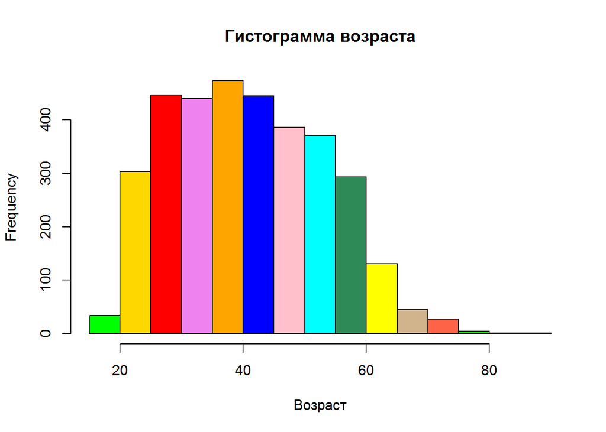

```r
colors = c("green", "gold", "red", "violet", "orange", "blue", "pink",
           "cyan", "seagreen", "yellow", "tan", "tomato")
hist(clear_data$Vozrast, xlab = "Возраст", main = "Гистограмма возраста", col = colors)
```

Ясно, что основная часть респондентов была в возрасте от 25 до 50 лет. Распределение очень похоже на нормальное, что не может не радовать:

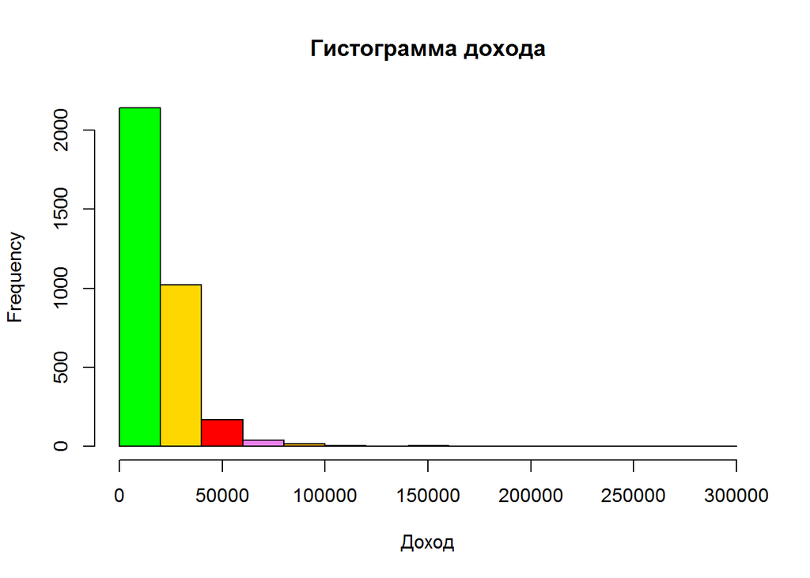

```r
hist(clear_data$Zarplata, xlab = "Доход", main = "Гистограмма дохода", col = colors)
```

Доход большей части респондентов расположился в районе 20000 р.

Построим модель, в которую включим все наши переменные и посмотрим на результаты:

```r
model_1 = lm(data = clear_data, Zarplata ~ Vozrast + Pol +
             SrSchool + Tech + VUZ + Alco_on_work + Courses)
coeftest(model_1)
```

```
##
## t test of coefficients:
##
##                                   Estimate Std. Error  t value  Pr(>|t|)
## (Intercept)                      23553.779   1791.123  13.1503 < 2.2e-16
## Vozrast                            -89.439     22.756  -3.9304  8.65e-05
## PolЖЕНСКИЙ                       -7755.521    565.479 -13.7150 < 2.2e-16
## SrSchool                         -2654.626   1956.582  -1.3568  0.174946
## Tech                              2271.462    705.674   3.2189  0.001299
## VUZ                              10709.734    668.572  16.0188 < 2.2e-16
## Alco_on_workНет                   1194.251   1024.135   1.1661  0.243653
## Alco_on_workЗАТРУДНЯЮСЬ ОТВЕТИТЬ  6883.957  11440.889   0.6017  0.547416
## Alco_on_workОТКАЗ ОТ ОТВЕТА       -887.249  16150.525  -0.0549  0.956193
## Alco_on_workНЕТ ОТВЕТА           -1141.381   5464.412  -0.2089  0.834558
## CoursesНет                         106.077   1110.927   0.0955  0.923935
##
## (Intercept)                      ***
## Vozrast                          ***
## PolЖЕНСКИЙ                       ***
## SrSchool
## Tech                             **
## VUZ                              ***
## Alco_on_workНет
## Alco_on_workЗАТРУДНЯЮСЬ ОТВЕТИТЬ
## Alco_on_workОТКАЗ ОТ ОТВЕТА
## Alco_on_workНЕТ ОТВЕТА
## CoursesНет
## ---
## Signif. codes:  0 '***' 0.001 '**' 0.01 '*' 0.05 '.' 0.1 ' ' 1
```

Что же, много интересного можно увидеть и здесь:

1. Estimate - 23533 - было видно из гистограммы дохода;
2. Женщины получают меньше на 7755 р при других равных переменных, что печалит;
3. По образованию все ожидаемо предсказуемо:
   - окончившие только 9 классов зарабатывают меньше на 2654, хотя не этот фактор у них является определяющим, см. p-value;
   - имеющие среднее специальное образование имеют больше на 2271:
   - выпускники ВУЗ’ов зарабатывают больше на 10709 и эта переменная очень важна.
4. Самое интересное - модель была построена на стандартных, пьющих на работе переменных. Все они не оказывают весомого влияния на зарплату. Но посмотреть на коэффициенты все равно крайне любопытно.
5. Не посещяющие курсов зарабатывают больше! Расходимся :( Но это неправда, так как p-value безумно велико, логично предположить, что среди респондентов очень мало людей, в чьих интересах продолжать свое обучение.

Список значимых переменных, которые необходимо включить в работу (требование условия задачи):

- Vozrast:
- Pol;
- Tech;
- VUZ.

Теперь посмотрим на модель, учитывая робастные ошибки:

```r
coeftest(model_1,vcov. = vcovHAC(model_1))
```

```
##
## t test of coefficients:
##
##                                   Estimate Std. Error  t value  Pr(>|t|)
## (Intercept)                      23553.779   1772.772  13.2864 < 2.2e-16
## Vozrast                            -89.439     22.144  -4.0391 5.486e-05
## PolЖЕНСКИЙ                       -7755.521    610.149 -12.7109 < 2.2e-16
## SrSchool                         -2654.626   1177.808  -2.2539 0.0242680
## Tech                              2271.462    593.879   3.8248 0.0001332
## VUZ                              10709.734    920.535  11.6343 < 2.2e-16
## Alco_on_workНет                   1194.251    907.759   1.3156 0.1883962
## Alco_on_workЗАТРУДНЯЮСЬ ОТВЕТИТЬ  6883.957   1968.101   3.4978 0.0004752
## Alco_on_workОТКАЗ ОТ ОТВЕТА       -887.249    980.020  -0.9053 0.3653508
## Alco_on_workНЕТ ОТВЕТА           -1141.381   2650.632  -0.4306 0.6667816
## CoursesНет                         106.077   1128.366   0.0940 0.9251069
##
## (Intercept)                      ***
## Vozrast                          ***
## PolЖЕНСКИЙ                       ***
## SrSchool                         *
## Tech                             ***
## VUZ                              ***
## Alco_on_workНет
## Alco_on_workЗАТРУДНЯЮСЬ ОТВЕТИТЬ ***
## Alco_on_workОТКАЗ ОТ ОТВЕТА
## Alco_on_workНЕТ ОТВЕТА
## CoursesНет
## ---
## Signif. codes:  0 '***' 0.001 '**' 0.01 '*' 0.05 '.' 0.1 ' ' 1
```

Объясняющих (имеющих малое p-value) переменных стало больше, что позволяет предположить в данных гетероскедастичность. Хотя все они балансируют на грани, но тем не менее. Значения с переменной употребления алкоголя заметно изменились в сторону значимости, но по-настоящему раскрылась “Затрудняюсь ответить”. То есть этот ответ устраивает всех нормальных людей - кто из нас может сказать, что он не пил на праздники на рабочем месте, но как ответить на это однозначно? Поэтому такое значение приобрела эта переменная. Тут имеет место корреляция, с какими - то другими переменными, жаль нет переменной “адекватность респондента” - с ней бы она коррелировала точно.

Список значимых переменных, которые необходимо включить в работу (требование условия задачи):

- Vozrast:
- Pol;
- SrSchool:
- Tech;
- VUZ;
- Alco_on_work.